# The ABC of Computational Text Analysis

#8 Ethics and the Evolution of NLP

Alex Flückiger

Faculty of Humanities and Social Sciences  
University of Lucerne

April 28, 2023

## Recap last Lecture

- assignment 2 accomplished ✅
- an abundance of data sources
  - JSTOR, Nexis, few datasets
- creating your own dataset
  - convert any data to `.txt`
- processing a batch of files
  - perform tasks in for-loop

## Outline

- ethics is everywhere 🙈🙉🙊
  - … and your responsibility
- understand the development of modern NLP 🚀
  - … or how to put words into computers

# **Ethics** is more than philosophy. It **is everywhere**.

# An Example

## You are applying for a job at a big company.

## Does your CV pass the automatic pre-filtering?

🔴 🟢

### 🤔 For what reasons?

## Your interview is recorded. 😎 🥵 What personal traits are inferred from that?

### 🤔 Is it a good reflection of your personality?

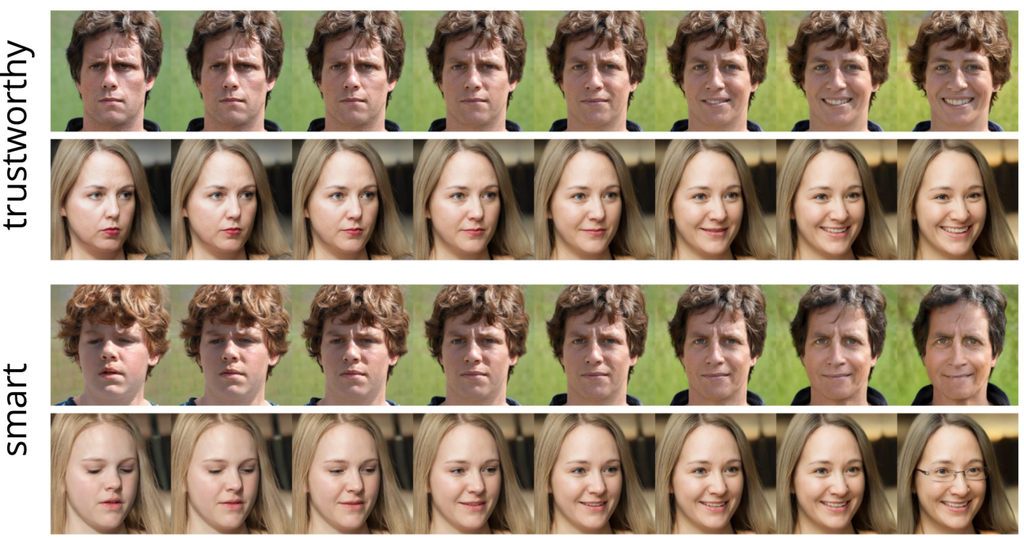

Face impressions as perceived by a model by (Peterson et al. 2022)

## Don’t worry about the future …

### … worry about the present.

- AI is persuasive in everyday’s life
  - assessing risks and performances (credits, job, crimes, terrorism etc.)
- AI is extremely capable
- AI is not so smart and often poorly evaluated

💡 What is going on behind the scene?

## Algorithmic Managment of Labour Force

[figure not shown]

ChatGPT may be used to communicate difficult desicions

# An (R)evolution of NLP

## From Bag of Words to Embeddings

### Putting Words into Computers (Smith 2020; Church and Liberman 2021)

- from **coarse, static** to **fine, contextual** meaning
- how to measure similarity of words
  - string-based
  - syntactic (e.g., part-of-speech)
  - semantic (e.g., animate)
  - embedding as abstract representations
- from counting to learning representations

## Bag of Words

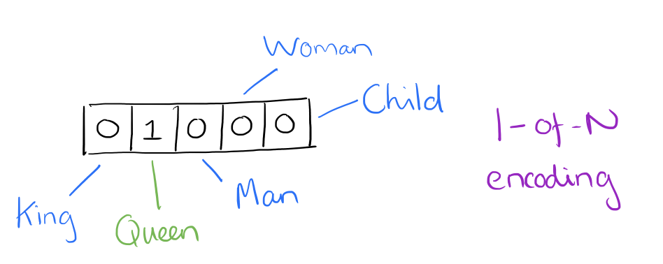

Discrete, symbolic words (Colyer 2016)

## Representing a Corpus

### Collection of Documents

1. `NLP is great. I love NLP.`
2. `I understand NLP.`
3. `NLP, NLP, NLP.`

### Document Term Matrix

|  | `NLP` | `I` | `is` | *term* |
| --- | --- | --- | --- | --- |
| **Doc 1** | 2 | 1 | 1 | … |
| **Doc 2** | 1 | 1 | 0 | … |
| **Doc 3** | 3 | 0 | 0 | … |
| *Doc ID* | … | … | … | *term frequency* |

## “I eat a hot `___` for lunch.”

> You shall know a word by the company it keeps!

> Firth (1957)

## Word Embeddings

### word2vec (Mikolov et al. 2013)

- words as continuous vectors
  - accounting for similarity between words
- semantic similarity
  - `King – Man + Woman = Queen`
  - `France / Paris = Switzerland / Bern`

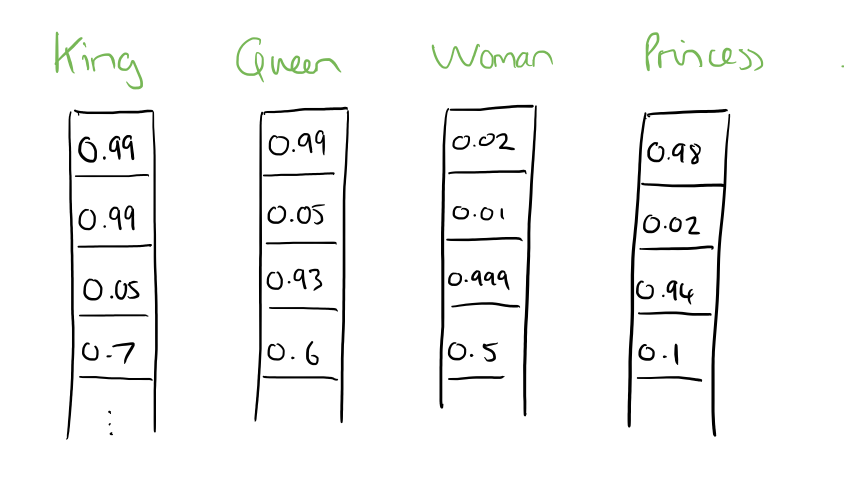

Single continuous vector per word (Colyer 2016)

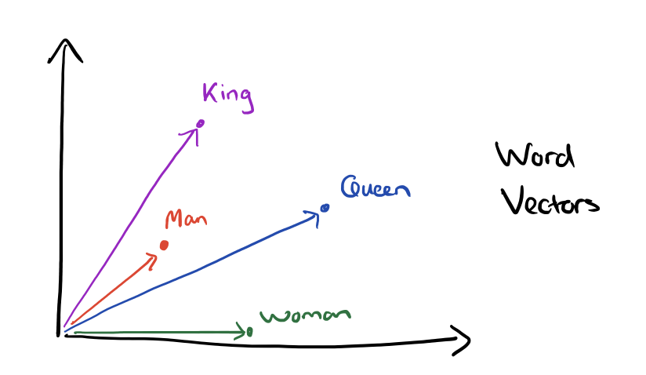

Words as points in a semantic space (Colyer 2016)

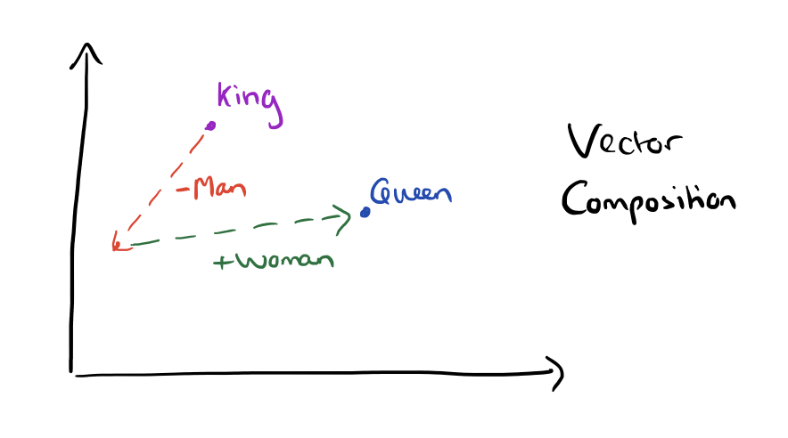

Doing arithmetics with words (Colyer 2016)

## Contextualized Word Embeddings

### BERT (Devlin et al. 2019)

- recontextualize static word embedding
  - different embeddings in different contexts
  - accounting for ambiguity (e.g., `bank`)
- acquire linguistic knowledge from language models (LM)
  - LM predict next/missing word
  - pre-trained on massive data (> 300 billions words)

💥 embeddings are the cornerstone of modern NLP

# Modern NLP is propelled by data

## Learning Associations from Data

«`___` becomes a doctor.»

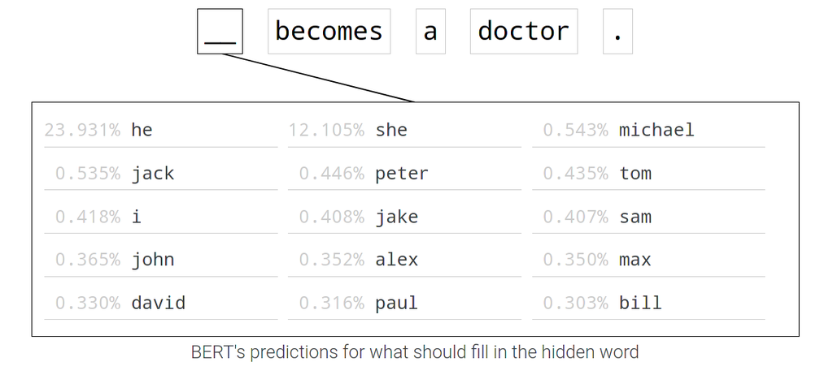

Gender bias of the commonly used language model [BERT](https://pair.withgoogle.com/explorables/fill-in-the-blank) (Devlin et al. 2019)

## Cultural Associations in Training Data

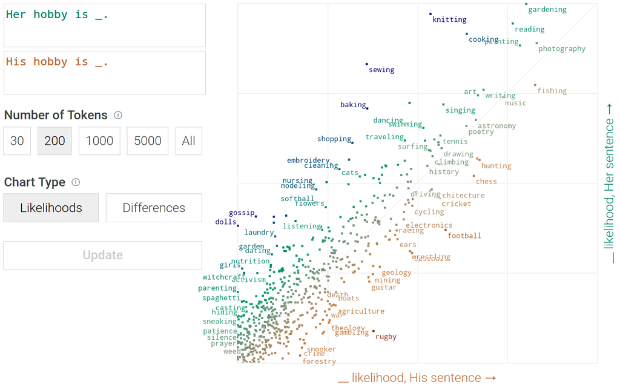

Gender bias of the commonly used language model [BERT](https://pair.withgoogle.com/explorables/fill-in-the-blank) (Devlin et al. 2019)

## Word Embeddings are biased …

### … because **our data** is we are biased. (Bender et al. 2021)

## In-class: Exercises I

1. Open the following website in your browser: https://pair.withgoogle.com/explorables/fill-in-the-blank/
2. Read the the article and play around with the interactive demo.
3. What works surprisingly well? What is flawed by societal bias? Where do you see limits of large language models?

# Modern AI = DL

## How does Deep Learning work?

### Deep Learning [works](https://thinc.ai/docs/backprop101) like a huge bureaucracy

1. **start** with **random** prediction
2. **blame** units for contributing to **wrong predictions**
3. **adjust** units based on the accounted blame
4. **repeat** the cycle

🤓 train with **gradient descent**, a series of **small steps** taken **to minimize an error function**

## Limitations of data-driven Deep Learning

„This sentence contains 32 characters.“  
„Dieser Satz enthält 32 Buchstaben.“

## Current State of Deep Learning

### Extremely powerful but … (Bengio, Lecun, and Hinton 2021)

- great at **learning patterns**, yet reasoning in its infancy
- requires tons of data due to inefficient learning
- generalizes poorly

# Biased Data and beyond

## Data = Digital Traces = Social Artifacts

- collecting, curating, preserving traces
- **data is imperfect**, always
  - social bias, noise, lack of data etc.
- data is more a **tool** to refine questions **rather than a reflection of the world**

## Data vs. Capta

> Differences in the etymological roots of the terms data and capta make the distinction between constructivist and realist approaches clear. *Capta* is **“taken”** actively while *data* is assumed to be a **“given”** able to be recorded and observed.

> Humanistic inquiry acknowledges the situated, partial, and constitutive character of knowledge production, the recognition that knowledge is constructed, *taken*, **not simply given as a natural representation** of pre-existing fact.

> Drucker (2011)

> Raw data is an oxymoron.

> Gitelman (2013)

## Two Sides of the AI Coin

### Explaining vs. Solving

- conduct **research to understand** matters in science
- **automate** matters **in business** using applied AI

## Still doubts about practical implications?

[figure not shown]

Gender bias in Google Translate

## And it goes on …

[figure not shown]

Gender bias in Google Translate

## Fair is a Fad

- companies also engage in fair AI to avoid regulation
- **Fair** and **good** – **but to whom?** (Kalluri 2020 )
- lacking democratic legitimacy

> Don’t ask if artificial intelligence is good or fair,  
> ask how it shifts power.

> Kalluri (2020)

## Data represents real life.

Don’t be a fool. Be wise, think twice.

# Questions?

## References

Bender, Emily M., Timnit Gebru, Angelina McMillan-Major, and Shmargaret Shmitchell. 2021. “On the Dangers of Stochastic Parrots: Can Language Models Be Too Big? 🦜.” In *Proceedings of the 2021 ACM Conference on Fairness, Accountability, and Transparency*, 610–23. Virtual Event Canada: ACM. https://doi.org/10.1145/3442188.3445922.

Bengio, Yoshua, Yann Lecun, and Geoffrey Hinton. 2021. “Deep Learning for AI.” *Communications of the ACM* 64 (7): 58–65. https://doi.org/10.1145/3448250.

Church, Kenneth, and Mark Liberman. 2021. “The Future of Computational Linguistics: On Beyond Alchemy.” *Frontiers in Artificial Intelligence* 4. https://doi.org/10.3389/frai.2021.625341.

Colyer, Adrian. 2016. “The Amazing Power of Word Vectors.” the morning paper. 2016. https://blog.acolyer.org/2016/04/21/the-amazing-power-of-word-vectors/.

Devlin, Jacob, Ming-Wei Chang, Kenton Lee, and Kristina Toutanova. 2019. “BERT: Pre-training of Deep Bidirectional Transformers for Language Understanding.” http://arxiv.org/abs/1810.04805.

Drucker, Johanna. 2011. “Humanities Approaches to Graphical Display.” *Digital Humanities Quarterly* 5 (1). http://www.digitalhumanities.org/dhq/vol/5/1/000091/000091.html.

Firth, John R. 1957. “A Synopsis of Linguistic Theory, 1930-1955.” In *Studies in Linguistic Analysis: Special Volume of the Philological Society*, edited by John R. Firth, 1–32. Oxford: Blackwell. http://ci.nii.ac.jp/naid/10020680394/.

Gitelman, Lisa. 2013. *Raw Data Is an Oxymoron*. Cambridge: MIT.

Kalluri, Pratyusha. 2020. “Don’t Ask If Artificial Intelligence Is Good or Fair, Ask How It Shifts Power.” *Nature* 583 (7815, 7815): 169–69. https://doi.org/10.1038/d41586-020-02003-2.

Mikolov, Tomas, Ilya Sutskever, Kai Chen, Greg S. Corrado, and Jeff Dean. 2013. “Distributed Representations of Words and Phrases and Their Compositionality.” In *Advances in Neural Information Processing Systems*, 3111–19.

Peterson, Joshua C., Stefan Uddenberg, Thomas L. Griffiths, Alexander Todorov, and Jordan W. Suchow. 2022. “Deep Models of Superficial Face Judgments.” *Proceedings of the National Academy of Sciences* 119 (17): e2115228119. https://doi.org/10.1073/pnas.2115228119.

Smith, Noah A. 2020. “Contextual Word Representations: Putting Words into Computers.” *Communications of the ACM* 63 (6): 66–74. https://doi.org/10.1145/3347145.